# INF Model V2

Tommy Lang

6/4/2018

# 1 Overview

The purpose of this document is to describe the methods used to identify individuals that  
have a tax liability within a subpopulation of non - filers that predominately do not even  
have a filing requirement.

# 2 Introduction

This Individual Non Filer (INF) project started in early 2017 to treat a subpopulation of  
non - filers identified as G and H. These groups have a connection to MA based on the MA  
Department of Revenue (DOR) receiving tax form data from the IRS under an exchange  
agreement. However, the large majority of the individuals in G and H do not have a tax  
liability with MA. For this reason the MA DOR have historically not treated these groups.  
The goal of this project was to identify individuals within G and H that did have a tax  
liability with MA.

We started by selecting random samples of individuals within G and H and sending them  
letters that stated that we believed that they owed taxes to MA for tax year 2013 and to  
call us if they believed we were wrong. There were two versions of this letter, one with a  
bill (Hard Letter) and one without a bill (Soft Letter). Certain types of responses from  
the Soft Letters were collected in Excel spreadsheets. Based on very negative feedback  
from letter recipients and DOR employees we filtered out certain types of individuals from  
being sent a letter. These filters changed over time.

In September of 2017 I started working on a predictive model using the responses from the  
Soft Letters. The model predicted whether or not a individual had a filing requirement but  
not necessarily a tax liability. At the time I did not believe the responses from Soft  
Letters would provide enough information to predict tax liability. The responses were  
mainly in the form of call logs where individuals may say that they are sending in a tax  
return but I wouldn’t be able to determine if it was a zero tax due return. Also I  
believed that that weren’t enough Hard Letters sent to build a model from that data at the  
time.

In December of 2017 about 16,000 Hard Letters were issued with about 4,600 of those  
letters based on model predictions that identified individuals that had a filling  
requirement. The letters were issued in a very short time frame and the feedback from  
letter recipients, DOR staff and management was extremely negative. However the responses  
from letter recipients that received letters based on the model predictions was  
substantially better in terms of call and payment volume.

In January of 2018 after realizing that predicting a filing requirement was not enough I  
started developing a model to predict whether or not individuals had a tax liability  
(INF Model V2). I tried using the same predictors as the first model and responses from  
the tax year 2013 Hard Letters but model performance was poor.

In February of 2018 I started creating different predictors for INF Model V2. I started  
off rigorously cleaning data and documenting my work but it was too time consuming. I had  
a hard deadline because I was resigning to go back to school. Therefore I applied the  
80/20 rule while preparing the data and creating the model. The model ended up being good  
enough despite not completing all of the steps that I should have. The goal was to have  
Precision $(\frac{TP} {TP + FP})$ of the model to be about 0.75 - 0.80 which it exceeds.  
This model or some iteration of it will be used to send letters to tax year 2014 Hard  
Letter recipients.

## 2.1 Packages and Custom Functions

The code chunks below are the functions, packages and variables I used for this document.

```r
LoadPackages <- function(packages) {
  # Load or install packages if they aren't already loaded.
  #
  # Args:
  #   packages: a vector of package names
  #
  for (package in packages) {
    if (!require(package, character.only=T, quietly=T)) {
      if (!package %in% installed.packages()) install.packages(package)
      library(package, character.only=T)
    }
  }
}
LoadPackages(c("readr", "dplyr", "Boruta", "data.table",
               "caret", "ggplot2", "binom", "boot",
               'ranger', "e1071", "rpart", "tidyr",
               'reshape2'))
```

```r
customSummary <- function (data, lev = NULL, model = NULL)
{
  lvls <- levels(data$obs)
  if (length(lvls) > 2)
    stop(paste("Your outcome has", length(lvls), "levels. The classSummary()
               function isn't appropriate."))
  if (!all(levels(data[, "pred"]) == lvls))
    stop("levels of observed and predicted data do not match")
  data$y = as.numeric(data$obs == lvls[2])
  prAUC <- MLmetrics::PRAUC(y_pred = data[, lev[1]], y_true =
                              ifelse(data$obs == lev[1], 1, 0))
  rocAUC <- ModelMetrics::auc(ifelse(data$obs == lev[2], 0,1), data[, lvls[1]])
  out <- c(prAUC, rocAUC,
           caret::sensitivity(data[, "pred"], data[, "obs"], lev[1]),
           caret::specificity(data[, "pred"], data[, "obs"], lev[2]),
           caret::precision(data = data$pred, reference = data$obs, relevant = lev[1]),
           caret::F_meas(data = data$pred, reference = data$obs, relevant = lev[1]))
  names(out) <- c("PR-AUC", "ROC-AUC", "Sens/Rec", "Spec", "Prec", "F")
  out
}
eightSummary <- function(...) c(customSummary(...), defaultSummary(...))
# ex. cutoffs(glmnet, eval, eval$overall_response, 400,700, 1000)
cutoffs <- function(model, test_set, response, low, high, divisor) {
  pred <- predict(model, test_set, type = "prob")
  cutoff <- low
  j <- 1
  metrics_cutoffs <- data.frame()
  for(i in low:high){
    cut <- cutoff / divisor

    colname <- paste0("cut",cut)
    pred[[colname]] <- ifelse(pred$pos > cut, "pos","neg")
    pred[[colname]] <- factor(pred[[colname]])
    pred[[colname]] <- relevel(pred[[colname]], "pos")
    cutoff <- cutoff +1

    cm <- caret::confusionMatrix(pred[[colname]], response, positive = "pos")
    metrics_cutoffs[j,1] <- cut
    metrics_cutoffs[j,2] <- cm$overall[1]
    metrics_cutoffs[j,3] <- cm$overall[2]
    metrics_cutoffs[j,4] <- cm$byClass[5]
    metrics_cutoffs[j,5] <- cm$byClass[6]
    metrics_cutoffs[j,6] <- cm$byClass[2]
    colnames(metrics_cutoffs) = c('Prob_Cutoff', 'Accuracy', "Kappa",
                                  "Precision", "Recall", "Specificity")
    j <- j+1
  }
  mets_pred <-  list(metrics_cutoffs,pred)
  return(mets_pred)
}
data <- '/data/aap/TL_WD/INF_TL/data/'
data3 <- '/data/aap/TL_WD/INF_TL/data/raw2/'
raw2 <- '/data/aap/TL_WD/INF_TL/data/raw2/'
raw14 <- '/data/aap/TL_WD/INF_TL/data/raw14/'
```

# 3 Response Variable

The response variable for the model is either positive (pos) or negative (neg). Ultimately  
pos is intended to mean that an individual has a tax liability and neg means that they  
don’t. The model predicts whether the letter recipient would have a pos or neg response  
given that they respond. It is based on the responses from the Hard Letters sent for tax  
year 2013. The precise definition of pos and neg is below:

Pos if one of the following criteria is met:  
- An original return was filed and the tax due is greater than zero.  
- Payments from tbl_payments but excluding ‘XOFABP’, ‘XOFCMP’, ‘XOFLOT’ payment types less  
garnishment payments is greater than zero and estimated return was not reversed.  
- Payments from tbl_payment but excluding ‘XOFABP’, ‘XOFCMP’, ‘XOFLOT’ payment types less  
garnishment payments is greater than zero and no return filed, no work item and no  
appeal case.  
- Payments from tbl_payment but excluding ‘XOFABP’, ‘XOFCMP’, ‘XOFLOT’ payment types less  
refunds from tblrfnrefund is greater than zero and no return filed.

Neg if one of the following criteria is met:  
- Return is filed and the tax due is zero.  
- There’s an appeal case or work item completed and estimated return is reversed and a  
tax return was not filed.  
- The estimated return is reversed and it wasn’t reversed by a member of the AA team and  
wasn’t reversed by the system and an original return was not filed.

The response variable changes over time. People may pay and then later on file a zero  
zero return or the system might just for some reason reverse the estimated return and  
issue a refund. The data I used for the response variable is as of 6/8/18.

If an individual meets criteria for both pos and neg then they are dropped from the  
training and testing data. There was 27 of these cases as of 6/8/18.

Certain types of payments and estimated returns reversed by a member of the AA team or the  
system was excluded to keep the response variable consistent. Some types of payments are  
not voluntary. The letter recipient may not necessarily agree with the notice but we may  
just take their funds without them knowing. The system will reverse estimated returns if  
the letter was returned as undeliverable. These are not responses from the letter  
recipient so they were filtered out before applying the criteria.

The bar chart below shows the number of positive and negative responses from the Hard  
Letters sent for tax year 2013.

```r
# The response variable was prepared in a separate file and read in here
resp <- read_rds(paste0(data,"hl_respv1_060818.rds"))
resp <- resp %>% dplyr::select(SSN, resp, discovery.key) %>%
  dplyr::mutate_at('resp', funs(as.factor))
resp$resp <- relevel(resp$resp, "pos")
```

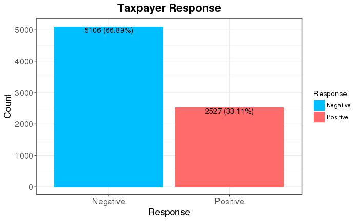

```r
resp_plot <- resp %>%
  mutate(Response = ifelse(resp == "pos", "Positive", "Negative"))
mod <- 412
n_mod_pos <- resp_plot %>% filter(resp == "pos" & discovery.key == mod) %>% nrow()
n_mod_neg <- resp_plot %>% filter(resp == "neg" & discovery.key == mod) %>% nrow()
n_mod_resp <- n_mod_pos + n_mod_neg
p_mod_pos <- ((n_mod_pos / n_mod_resp) * 100) %>% round(2)
n_pos <- resp_plot %>% filter(resp == "pos") %>% nrow()
n_neg <- resp_plot %>% filter(resp == "neg") %>% nrow()
p_pos <- n_pos / (n_pos + n_neg) * 100
p_pos <- round(p_pos,digits = 2)
p_neg <- n_neg / (n_pos + n_neg) * 100
p_neg <- round(p_neg ,digits = 2)
pos_info <- paste0(n_pos, " ", "(", p_pos, "%", ")")
neg_info <- paste0(n_neg, " ", "(", p_neg, "%", ")")
resp_plot2 <- data.frame("Response" = c("Positive", "Negative"),
                         "Count" = c(n_pos, n_neg),
                         "Text" = c(pos_info, neg_info))
ggplot(resp_plot2, aes(x = Response, y = Count, fill = Response)) +
  geom_col() +
  theme_bw() +
  labs(title = "Taxpayer Response") +
  scale_fill_manual("Response", values =
                      c("Positive" = "indianred1", "Negative" = "#00BFFF")) +
  geom_text(aes(y = Count, label = Text, vjust= 1.1), size = 4) +
  theme(plot.title = element_text(hjust = .5, size = 16, face = "bold"),
        axis.text=element_text(size=12),
        axis.title=element_text(size=14))
```

Out of these responses 1551 are from predictions of the first INF Model and 73.37% of  
the these responses are positive. This is consistent with expectations and the results  
from the evaluating that model on the test set.

# 4 Predictor Variables

The predictor variables used are derived from Information Returns Master File (IRMF) data  
that the DOR receives from the IRS, MA withholding data, MA tax filing history, driver’s  
license data from the RMV and potential letter recipient addresses. The data was prepared  
in a separate file and read in here.

The abbreviations MA, NMA, NTS, and HFS mean MA state, Non MA state, No Tax State, High  
Frequency State respectively and they refer to the payee state on the IRMF Form.

The abbreviations 1yb, cy and 1yf mean 1 year before target year, current target year, and  
1 year forward of target year respectively.

These variables were primarily designed and selected based from expert knowledge.

```r
all_features <- read_rds(paste0(data, "features_V2_2013.rds"))  %>%
  dplyr::select(-cy_withheld_zscore)
predictor_names <- all_features %>% dplyr::select(-ext_ssn) %>% names() %>%
  as.data.frame()
names(predictor_names) <- c("Predictor_Name")
predictor_names
```

| Predictor_Name |
| --- |
| MA_income_1yb |
| MA_income_cy |
| MA_income_1yf |
| NTS_income_1yb |
| NTS_income_cy |
| NTS_income_1yf |
| HFS_income_1yb |
| HFS_income_cy |
| HFS_income_1yf |
| NMA_income_1yb |

[output cut: 43 more lines]

```r
# join the predictors with the response variable
all <- resp %>% dplyr::inner_join(all_features, c("SSN" = "ext_ssn")) %>%
  dplyr::select(-SSN, -discovery.key)
```

# 5 Feature Selection

I used Boruta package to help narrow down the optimal set of predictors (Kursa). Many  
machine learning algorithms will have a decrease in performance when the number of  
variables is not optimal. The Boruta algorithm is a novel feature selection method that is  
designed as a wrapper around the Random Forest Algorithm (Boruta is a god of the forest  
in the Slavic mythology). It iteratively removes the predictors which are suggested by a  
statistical test to be less relevant than random probes. The algorithm confirmed that all  
of the predictors except one is significant. The table below shows the results from  
running the algorithm:

```r
set.seed(888)
boruta_train <- Boruta(resp ~., data = all, doTrace = 2, maxRuns = 88)
```

```r
# print(boruta_train)
final_boruta <- TentativeRoughFix(boruta_train)
# print(final_boruta)
imp_predictors <- getSelectedAttributes(final_boruta, withTentative = F)
boruta_df <- setDT(attStats(final_boruta), keep.rownames =TRUE)[]
imp <- all[ ,c("resp", imp_predictors)]
```

```r
# Results of from the Boruta Algorithm
boruta_df %>% arrange(desc(meanImp))
```

| rn | meanImp | medianImp | minImp | maxImp | normHits | decision |
| --- | --- | --- | --- | --- | --- | --- |
| NMA_income_cy | 32.431379 | 32.488410 | 30.0076806 | 34.918216 | 1.00000000 | Confirmed |
| MA_income_cy | 32.260351 | 32.178087 | 29.9525913 | 34.559973 | 1.00000000 | Confirmed |
| ma_form_cy_cnt | 31.749643 | 31.722499 | 28.7793609 | 34.167266 | 1.00000000 | Confirmed |
| MA_withheld_cy | 30.763533 | 30.763093 | 28.1101372 | 33.031302 | 1.00000000 | Confirmed |
| notMA_form_cy_cnt | 25.944902 | 25.944265 | 23.6499560 | 27.903557 | 1.00000000 | Confirmed |
| NMA_income_1yb | 25.041061 | 25.015953 | 22.8296797 | 26.784829 | 1.00000000 | Confirmed |
| NMA_income_1yf | 22.604348 | 22.638062 | 20.4204543 | 24.900755 | 1.00000000 | Confirmed |
| is_pop_g | 21.839754 | 21.871430 | 19.4216620 | 23.251106 | 1.00000000 | Confirmed |
| notMaPayeeAndPayer_cy_w2 | 21.515568 | 21.526904 | 19.1959304 | 23.682511 | 1.00000000 | Confirmed |
| mail_MA | 21.070950 | 21.060499 | 19.4430196 | 22.823064 | 1.00000000 | Confirmed |

[output cut: 43 more lines]

# 6 Model Selection

The data was split into a training, evaluation and a test set using stratified random  
sampling to preserve class balance. Four types of models (RandomForest, Elastic Net  
Regression, Recursive Partitioning Trees and K - Nearest Neighbors) were created. The more  
important parameters were tuned using 10 fold cross validation with 5 repeats. Other less  
important parameters were set to the default values to save time. The area under the  
precision recall curve was used to select the optimal model. This metric provides useful  
insights into future model performance because the positive class is mainly what we’re  
interested in.

```r
# Create train, evaluation and test sets
set.seed(88)
split_index_train <- createDataPartition(imp$resp, p = .7, list = FALSE)
train <- imp[split_index_train,]
not_train <- imp[-split_index_train,]
split_index_eval <- createDataPartition(not_train$resp, p = .4, list = FALSE)
eval <- not_train[split_index_eval,]
test <- not_train[-split_index_eval,]
```

```r
ctrl <- trainControl(method = "repeatedcv", number = 10, repeats = 5,
                     summaryFunction = eightSummary,
                     classProbs = TRUE, verboseIter = TRUE)

len <- 20

set.seed(888)
rf <- train(resp ~ ., data = train, tuneLength = len, num.tree = 2000,
            importance = 'impurity', metric = "PR-AUC", method = "ranger",
            trControl = ctrl)

set.seed(888)
glmnetGrid <- expand.grid(alpha = seq(0,1, length = len),
                          lambda = seq(0.0001, 1, length = 100))
glmnet <- train(resp ~ ., data = train, tuneGrid = glmnetGrid,
                preProcess = c("center", "scale"), metric = "PR-AUC",
                method = "glmnet", trControl = ctrl)

set.seed(888)
rpart <- train(resp ~ ., data = train, tuneLength = len,
                 metric = "PR-AUC", method = "rpart", trControl = ctrl)

set.seed(888)
knn <- train(resp ~ ., data = train, tuneLength = len,
             preProcess = c("center", "scale"), metric = "PR-AUC",
             method = "knn", trControl = ctrl)

saveRDS(rf, paste0(data,"INF_V2_rf.rds"))
saveRDS(glmnet, paste0(data,"INF_V2_glmnet.rds"))
saveRDS(rpart, paste0(data,"INF_V2_rpart.rds"))
saveRDS(knn, paste0(data,"INF_V2_knn.rds"))
```

```r
# Don't want to run the algos everytime I knit the document so I saved them and load them
# back in here
rf <- readRDS(paste0(data,"INF_V2_rf.rds"))
glmnet <- readRDS(paste0(data,"INF_V2_glmnet.rds"))
rpart <- readRDS(paste0(data,"INF_V2_rpart.rds"))
knn <- readRDS(paste0(data,"INF_V2_knn.rds"))
```

## 6.1 Comparisons

The box plots in the plot below shows the performance metric for each fold and each repeat  
from cross validation for each model type. The dot in the middle of each box is the mean  
of the respective performance metric. Box plots are useful for looking at the spread of a  
statistic. The plot shows that the RandomForest model performs the best across all of the  
metrics and the spread looks acceptable. Therefore the RandomForest model will be used to  
make predictions.

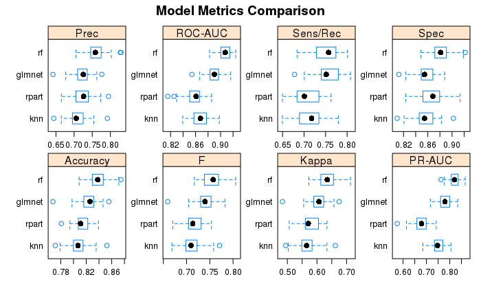

```r
# resamples checks that the models are comparable and that they used the same
# training scheme (trainControl config). This object contains the evaluation metrics for
# each fold and each repeat for each evaluated algorithm
results <- resamples(list(rf = rf, glmnet = glmnet, rpart = rpart, knn = knn))
# summary(results)
scales <- list(x=list(relation="free"), y=list(relation="free"))
bwplot(results, scales=scales, main = "Model Metrics Comparison")
```

## 6.2 Vairable Importance

The plot below shows the top 15 most important predictors in the RandomForest model. The  
importance measure is based on total decrease in node impurities from splitting on the  
variable, averaged over all trees.

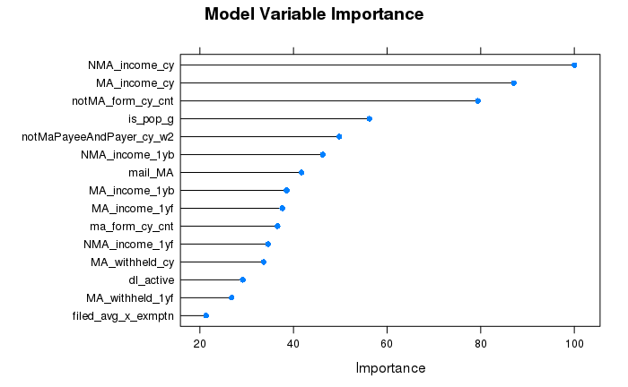

```r
plot(varImp(rf), top = 15, main = "Model Variable Importance")
```

# 7 Validation and Ajustments

Here the RandomForest model is validated using the evaluation and test sets. Also some  
additional adjustments are made to the predictions.

## 7.1 Evaluation Set

The performance metrics of the final model on the evaluation set is below:

```r
pred_prob <- predict(rf, eval, type = "prob")[, "pos"]
# PR AUC
eval_pr <- MLmetrics::PRAUC(y_true = eval$resp,  y_pred = pred_prob) %>%
  round(4)
print(paste0("The area under the PR curve is: ", eval_pr))
```

```
[1] "The area under the PR curve is: 0.8338"
```

```r
# ROC AUC
eval_auc <- pROC::auc(eval$resp, pred_prob) %>% as.data.frame()
print(paste0("The area under the ROC curve is: ", round(eval_auc$.,4)))
```

```
[1] "The area under the ROC curve is: 0.9134"
```

```r
# Confusion Matrix
caret::confusionMatrix(predict(rf, eval), eval$resp)
```

```
Confusion Matrix and Statistics

          Reference
Prediction pos neg
       pos 238  73
       neg  66 540

               Accuracy : 0.8484
                 95% CI : (0.8235, 0.871)
    No Information Rate : 0.6685
    P-Value [Acc > NIR] : <2e-16

                  Kappa : 0.66
 Mcnemar's Test P-Value : 0.6108

            Sensitivity : 0.7829
            Specificity : 0.8809
         Pos Pred Value : 0.7653
         Neg Pred Value : 0.8911
             Prevalence : 0.3315
         Detection Rate : 0.2595
   Detection Prevalence : 0.3391
      Balanced Accuracy : 0.8319

       'Positive' Class : pos
```

### 7.1.1 Alternative Probability Cutoff

An alternative probability cutoff for the predictions is chosen in favor of precision  
$(\frac{TP} {TP + FP})$ while balancing recall $(\frac{TP} {TP + FN})$. This will increase the number of false  
negatives and therefore decrease the number letters that this model will suggest to send.  
However the proportion of true positives to positive predictions (precision) will increase  
(more accurate positive predictions). The false negatives that will be left behind can be  
treated with an improved iteration of this model (the false negatives from this model will  
be predicted as positive with a better model). Therefore we don’t lose any potential  
revenue by favoring precision for the first iteration of the model.

The line plot below shows the value of accuracy, precision and recall with each alternative  
probability cutoff. The dotted vertical line indicates the value of the chosen alternative  
probability cutoff.

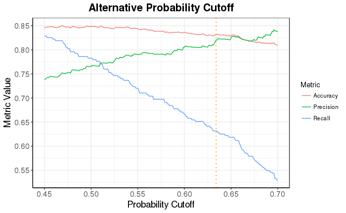

```r
alt_prob <- cutoffs(rf, eval, eval$resp, 450,700, 1000)[1] #0.585 looks good
cut <- 0.634
alt_prob_plot <- as.data.frame(alt_prob) %>%
  dplyr::select(Prob_Cutoff, Accuracy, Precision, Recall) %>%
  melt(id = "Prob_Cutoff") %>%
  mutate(Metric = variable)
ggplot(alt_prob_plot, aes(x = Prob_Cutoff, y = value, color = Metric)) +
  geom_line() +
  labs(title = "Alternative Probability Cutoff",
       x = "Probability Cutoff",
       y = "Metric Value") +
  theme_bw() +
  theme(plot.title = element_text(hjust = .5, size = 16, face = "bold"),
        axis.text=element_text(size=12),
        axis.title=element_text(size=14),
        axis.line = element_line(colour = "black")) +
  scale_y_continuous(breaks = seq(.5,.95, by =.05)) +
  geom_vline(xintercept = cut, linetype="dotted",
                color = "orange1", size=.7)
```

## 7.2 Test Set

The performance metrics of the final model on the test set with the alternative probability  
cutoff is below:

```r
pred_prob <- predict(rf, test, type = "prob")[, "pos"]
# PR AUC
test_pr <- MLmetrics::PRAUC(y_true = test$resp, y_pred = pred_prob) %>%
  round(4)
print(paste0("The area under the PR curve is: ", test_pr))
```

```
[1] "The area under the PR curve is: 0.8186"
```

```r
# ROC AUC
test_auc <- pROC::auc(test$resp, pred_prob ) %>% as.data.frame()
print(paste0("The area under the ROC curve is: ", round(test_auc$.,4)))
```

```
[1] "The area under the ROC curve is: 0.9014"
```

```r
pred_prob <- data_frame("pos" = pred_prob)
pred_class <- pred_prob %>% mutate(pred = ifelse(pos >= cut, "pos", "neg"))
pred_class$pred <- factor(pred_class$pred)
pred_class$pred <- relevel(pred_class$pred, "pos")
# Confusion Matrix
caret::confusionMatrix(pred_class$pred, test$resp)
```

```
Confusion Matrix and Statistics

          Reference
Prediction pos neg
       pos 266  52
       neg 188 866

               Accuracy : 0.8251
                 95% CI : (0.8039, 0.8448)
    No Information Rate : 0.6691
    P-Value [Acc > NIR] : < 2.2e-16

                  Kappa : 0.5726
 Mcnemar's Test P-Value : < 2.2e-16

            Sensitivity : 0.5859
            Specificity : 0.9434
         Pos Pred Value : 0.8365
         Neg Pred Value : 0.8216
             Prevalence : 0.3309
         Detection Rate : 0.1939
   Detection Prevalence : 0.2318
      Balanced Accuracy : 0.7646

       'Positive' Class : pos
```

## 7.3 Predictor Space Evaluation

Model performance on unseen data will be very similar to how it performs on the test set  
if the test set is a representative sample of the unseen data. This means that the unseen  
observations will have similar characteristics and will occupy similar parts of the  
predictor space as the data the model was trained on. Here I use a variation of a method  
described by Hastie et al. (2008) to identify whether or not a new observation is from  
the training data. A classification model is created to predict whether or not a new  
observation is a member of the training data. I refer to this as the Similarity Model.

```r
# Randomly permute the predictors from the training set
# Row bind the original training data on top of the permuted data
# Create a classification vector that identifies the training and permuted data
set.seed(44)
train_pred <- train %>% dplyr::select(-resp)
permute_train <- apply(train_pred, 2, function(x) sample(x))
sim_x <- rbind(train_pred, permute_train)
group_vals <- c("train", "random")
group_y <- factor(rep(group_vals, each = nrow(train_pred)))
sim_x$train <- group_y
sim_x <- sim_x %>%
  dplyr::mutate(train = ifelse(train == "train", "pos", "neg")) %>%
  dplyr::mutate_at("train", as.factor)
sim_x$train <- relevel(sim_x$train, "pos")
```

```r
# Create train and test splits
set.seed(8)
index_sim <- createDataPartition(sim_x$train, p = .8, list = FALSE)
train_sim <- sim_x[index_sim,]
test_sim <- sim_x[-index_sim,]
```

```r
# Train a classification model to predict if an observation is a member of the training set
ctrl2 <- trainControl(method = "cv", number = 10,
                     summaryFunction = eightSummary,
                     classProbs = TRUE, verboseIter = TRUE)
set.seed(88)
rf_sim <- train(train ~., data = train_sim, importance = 'impurity',
                method = "ranger", tuneLength = 20,
                trControl = ctrl2, metric = "Prec")
```

The performance of the Similarity Model on a test set is shown below:

```r
# Confusion Matrix
caret::confusionMatrix(predict(rf_sim, test_sim), test_sim$train)
```

```
Confusion Matrix and Statistics

          Reference
Prediction  pos  neg
       pos 1012   11
       neg   56 1057

               Accuracy : 0.9686
                 95% CI : (0.9603, 0.9756)
    No Information Rate : 0.5
    P-Value [Acc > NIR] : < 2.2e-16

                  Kappa : 0.9373
 Mcnemar's Test P-Value : 7.639e-08

            Sensitivity : 0.9476
            Specificity : 0.9897
         Pos Pred Value : 0.9892
         Neg Pred Value : 0.9497
             Prevalence : 0.5000
         Detection Rate : 0.4738
   Detection Prevalence : 0.4789
      Balanced Accuracy : 0.9686

       'Positive' Class : pos
```

The Similarity Model is used to predict whether or not an observation in 2014 G and H  
groups is a member of the training data used to build the INF Model V2. The model  
predictions and proportion table below suggests that the large majority of 2014  
observations is represented in the training data.

```r
features_14 <- read_rds(paste0(data, "features_V2_2014.rds"))
sim_pred_14 <- predict(rf_sim, features_14) %>% as.data.table()
names(sim_pred_14) <- "sim_predict"
prop.table(table(sim_pred_14$sim_predict))
```

```
       pos        neg
0.92004837 0.07995163
```

## 7.4 Additional Adjustments

Two adjustments to the INF Model predictions are made to increase precision, prevent  
extrapolated predictions and to make the predictions more sensible. As I explained before,  
precision is favored over recall because we are sending letters to people with positive  
predictions. A bad letter can’t be un-sent but a good letter that wasn’t sent can later  
be sent by creating better iteration of this model to identify the false negatives  
that were left behind.

The first adjustment is to adjust all predictions as negative if the Similarity Model  
predicts that the observation is not a member of the training set used to create the INF  
Model. This helps prevent extrapolated predictions which may be unreliable. The second  
adjustment is to adjust all predictions as negative if the current target year MA income  
is less than $8,000. My definition of MA income is loose and if an observation doesn’t  
have at least $8,000 of it then there is only a small chance of that observation even  
having a filing requirement. This increases precision and makes the predictions more  
sensible so that we receive less negative feedback from stakeholders.

These adjustments should be reevaluated in the future. I included these now because there  
is additional risk from using a model built from responses of one tax year to predict  
responses of another tax year. Predictive models assume that the underlying system that  
generated the current data for training the model will continue to generate future data.  
The majority of the data used for the model is IRMF data from IRS and they may make  
changes to how it is generated from year to year. Also, the groups G and H are defined  
differently from year to year.

```r
# use rf_sim on test set
sim_predict <- predict(rf_sim, test) %>% as.data.table()
names(sim_predict) <- "sim_predict"
inc_predict <- test %>%
  dplyr::mutate(inc_predict = ifelse(MA_income_cy > 8000, "pos", "neg")) %>%
  dplyr::select(inc_predict)
```

# 8 Performance

Performance of the INF Model with the additional adjustments are evaluated here. Also a  
few different types of confidence intervals are created to get an idea of how precision  
may vary between letter batches (samples).

Below is a confusion matrix and related statistics for the test set with the adjustments:

```r
mod_predict <- predict(rf, test, type = "prob")
final_predict <- bind_cols(mod_predict, inc_predict, sim_predict) %>%
  mutate(final_predict = ifelse(pos >= cut &
                                inc_predict == "pos" &
                                sim_predict == "pos", "pos", "neg")) %>%
  mutate_at("final_predict", funs(as.factor(.)))
final_predict$final_predict <- relevel(final_predict$final_predict, "pos")
caret::confusionMatrix(final_predict$final_predict, test$resp)
```

```
Confusion Matrix and Statistics

          Reference
Prediction pos neg
       pos 247  47
       neg 207 871

               Accuracy : 0.8149
                 95% CI : (0.7933, 0.8351)
    No Information Rate : 0.6691
    P-Value [Acc > NIR] : < 2.2e-16

                  Kappa : 0.541
 Mcnemar's Test P-Value : < 2.2e-16

            Sensitivity : 0.5441
            Specificity : 0.9488
         Pos Pred Value : 0.8401
         Neg Pred Value : 0.8080
             Prevalence : 0.3309
         Detection Rate : 0.1800
   Detection Prevalence : 0.2143
      Balanced Accuracy : 0.7464

       'Positive' Class : pos
```

## 8.1 Confidence Intervals

A confidence interval for precision loosely quantifies the level of confidence that the  
true value of precision lies in the interval. It attempts to provide insight into what  
precision of the model would be if we sent everyone a letter and collected the responses.  
It does this by creating an interval with a specified level of confidence that represents  
the frequency of possible confidence intervals that contain the true value of precision if  
we had infinite number of samples.

I created a few different types of 95% confidence intervals and compared them.

The bootstrap percentile confidence interval is the most intuitive to understand and is  
created by taking random samples with replacement from the test set and corresponding  
predictions and then calculating precision for each sample. This type of sampling is  
called bootstrapping and it creates a sampling distribution that is usually very similar  
to sampling from the population. I sometimes refer to bootstrap confidence interval  
methods as simulation confidence intervals for this reason. In a 95% bootstrap percentile  
confidence interval the lower bound is the precision value that corresponds with the 2.5  
percentile and the upper bound is the precision value that corresponds with the 97.5  
percentile.

```r
test_sample <- data_frame(final_predict$final_predict, test$resp)
names(test_sample) <- c("pred", "actual")
set.seed(888)
B <- 100000
prec_boot <- numeric(B)
 for (i in 1:B) {
   index <- sample(1:nrow(test_sample), nrow(test_sample), replace = TRUE)
   test_sample2 <- test_sample[index, ]
   prec_boot[i] <-  MLmetrics::Precision(test_sample2$actual,
                                      test_sample2$pred,
                                      positive = "pos")
 }
```

A density plot of the precision values from bootstrapping is shown below. This shows the  
distribution of the precision values from the 100,000 resamples. The x axis labels contain  
the minimum, median, and maximum values of precision. It also contains the lower and upper  
bounds of the 95% confidence interval.

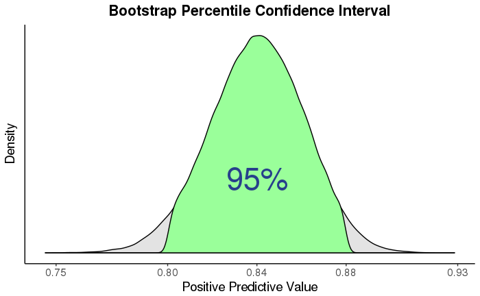

```r
min_prec <- round(min(prec_boot),2)
max_prec <- round(max(prec_boot),2)
h_prec <- round(quantile(prec_boot, c(0.975)), 2) %>% unname()
l_prec <- round(quantile(prec_boot, c(0.025)), 2) %>% unname()
m_prec <- round(quantile(prec_boot, c(0.5)), 2) %>% unname()
prec_df <- data.frame(prec_boot)
prec_df <- prec_df %>% mutate(ci_95 = ifelse(prec_boot < h_prec &
                                    prec_boot > l_prec, 1, 0))
prec_df_95 <- prec_df %>% filter(ci_95 == 1)
ggplot(data = prec_df, aes(x = prec_boot)) +
  geom_density(color = "black", fill = "grey89")  +
  geom_density(data = prec_df_95, color = "black", fill = "palegreen1") +
  annotate("text", x= m_prec, y= 6.8,
           label = "95%", size = 12, color = 'royalblue4') +
  scale_x_continuous(breaks=c(min_prec, max_prec, m_prec, h_prec, l_prec)) +
  labs(title = "Bootstrap Percentile Confidence Interval",
       x = "Positive Predictive Value",
       y = "Density") +
  theme(plot.title = element_text(hjust = .5, size = 16, face = "bold"),
        axis.text=element_text(size=12),
        axis.title=element_text(size=14),
        panel.background = element_blank(),
        axis.line = element_line(colour = "black"),
        axis.text.y=element_blank(),
        axis.ticks.y=element_blank())
```

I also created a 95% Bias Corrected and Accelerated (BCA) confidence interval. It’s  
another type of bootstrap confidence interval and it has the benefit of being of being  
range preserving, transformation invariant and second-order accurate.

```r
Prec <- function(d, i) {
  d2 <- d[i, ]
  precision <- MLmetrics::Precision(d2$actual,
                                      d2$pred,
                                      positive = "pos")
  return(precision)
}
```

```r
boot_prec <- boot::boot(test_sample, Prec, R = 100000)
boot_prec
summary(boot_prec)
bca_95 <- boot.ci(boot.out = boot_prec, conf = 0.95, type = c('bca'))
bca_lower <- as.data.frame(bca_95$bca)$V4
bca_upper <- as.data.frame(bca_95$bca)$V5
```

The other two types confidence intervals I created used normal approximation and Wilson  
score.

The plot below compares the 4 different types of confidence intervals.

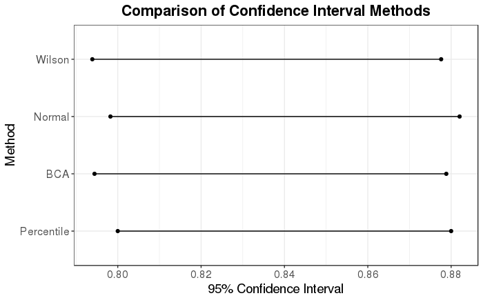

```r
TP <- test_sample %>% filter(pred == "pos" & actual == "pos") %>% nrow()
FP <- test_sample %>% filter(pred == "pos" & actual == "neg") %>% nrow()
n <- TP + FP
p <- TP / (TP+FP)
# Check if assumption is met for normal approximation
# n*p
# n*(1-p)
ci <- binom.confint(TP, n, conf.level = .95,
                         methods = c("asymptotic", "wilson")) %>%
  dplyr::select(method, lower, upper) %>%
  mutate_at("method", funs(as.character(.)))
b_ci <- data_frame("method" = c("Percentile", "BCA"),
                   'lower' = c(l_prec, bca_lower),
                   "upper" = c(h_prec, bca_upper))
ci_plot <- b_ci %>%
  bind_rows(ci)
ci_plot$method <- ci_plot$method %>%
  str_replace_all(c("asymptotic", "wilson"), c("Normal", "Wilson"))
ci_plot <- ci_plot %>% melt(id = "method") %>%
  mutate_at("method", funs(as.factor(.)))
ci_plot$method <- relevel(ci_plot$method, ref = "Percentile")
ggplot(ci_plot, aes(y = method, x = value)) + geom_point() + geom_line() +
labs(title = "Comparison of Confidence Interval Methods",
     y = "Method", x = "95% Confidence Interval") +
  theme_bw() +
  theme(plot.title = element_text(hjust = .5, size = 16, face = "bold"),
        axis.text=element_text(size=12),
        axis.title=element_text(size=14))
```

```r
NA
```

# 9 2014 Predictions

The predictor variables for 2014 observations were prepared in a separate file and read  
into this document in section 7.3. Here I used the INF Model to make predictions on the  
2014 observations and then made the adjustments to the predictions as previously described  
in section 7.4. The predictions are saved in a text file and the team will use it to help  
determine which observations should receive a letter.

```r
mod_pred_14 <- predict(rf, features_14, type = "prob")
inc_pred_14 <- features_14 %>%
  dplyr::mutate(inc_predict = ifelse(MA_income_cy > 8000, "pos", "neg")) %>%
  dplyr::select(ext_ssn, inc_predict, is_pop_g)
final_pred_14 <- bind_cols(inc_pred_14, mod_pred_14, sim_pred_14) %>%
  dplyr::mutate(final_pred =  ifelse(pos >= cut &
                              inc_predict == "pos" &
                              sim_predict == "pos", "pos", "neg"),
         pop_group = ifelse(is_pop_g == 1, "G", "H"),
         ssn = ext_ssn,
         prediction = final_pred) %>%
  dplyr::mutate(pos = round(pos, 9)) %>%
  dplyr::mutate(neg = round(neg, 9)) %>%
  dplyr::select(ssn, pop_group, pos, neg, prediction)
#write_tsv(final_pred_14, paste0(data, "INF_V2_14_Predictions.txt"))
```

The bar chart below shows the number of negative and positive predictions. It also shows  
the negative predictive value (NPV) and positive predictive value (PPV / precision) from  
the test set in section 8. This gives an indication of how accurate the negative and  
positive predictions will be respectively. It’s important to remember that the prediction  
is whether the response of a letter recipient is positive or negative as described in  
section 3 given that they respond (I’ll discuss non-response bias later). Also, I should  
point out again that a response for a observation can change over time and that the  
responses used to build the model had 6+ months to be recorded. Therefore the prediction  
is really what the response would be after 6+ months.

$NPV = \frac{TN} {TN + FN}$

$PPV = \frac{TP} {TP + FP}$

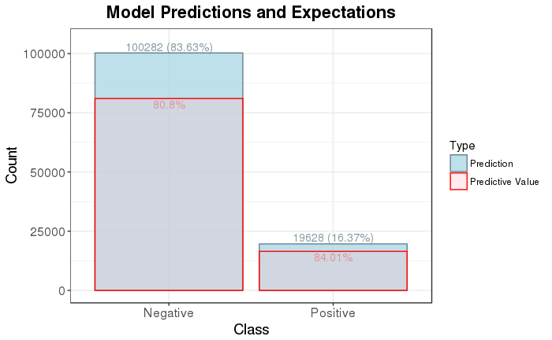

```r
n_pos <- final_pred_14 %>% filter(prediction == "pos") %>% nrow()
n_neg <- final_pred_14 %>% filter(prediction == "neg") %>% nrow()
p_pos <- n_pos / (n_pos + n_neg) * 100
p_pos <- round(p_pos,digits = 2)
p_neg <- n_neg / (n_pos + n_neg) * 100
p_neg <- round(p_neg ,digits = 2)
pos_info <- paste0(n_pos, " ", "(", p_pos, "%", ")")
neg_info <- paste0(n_neg, " ", "(", p_neg, "%", ")")
# NPV and PPV from test set
PPV <- ((TP / (TP + FP)) * 100) %>% round(2)
PPV_n <- ((PPV / 100) * n_pos) %>% round(0)
TN <- test_sample %>% filter(pred == "neg" & actual == "neg") %>% nrow()
FN <- test_sample %>% filter(pred == "neg" & actual == "pos") %>% nrow()
NPV <- ((TN / (TN + FN)) * 100) %>% round(2)
NPV_n <- ((NPV / 100) * n_neg) %>% round(0)
ppv_info <- paste0( PPV, "%")
npv_info <- paste0(NPV, "%")
pred_plot <- data.frame("Class" = c("Positive", "Negative", "Positive", "Negative"),
                        "Type" = c("Prediction", "Prediction",
                                   "Predictive Value", "Predictive Value"),
                        "Count" = c(n_pos, n_neg, PPV_n, NPV_n),
                        "Text" = c(pos_info, neg_info, ppv_info, npv_info),
                        "text_cnt" = c(n_pos + 5100, n_neg + 5100, PPV_n, NPV_n))
# important to note here that model predicts the response given a response so
# not appropriate to include number of responses from NPV and PPV
ggplot(data = pred_plot, aes(x = Class,
                             y = Count,
                             fill = Type,
                             color = Type,
                             alpha = Type)) +
  geom_bar(stat = 'identity', position = "identity") +
  labs(title = "Model Predictions and Expectations") +
  theme_bw() +
  theme(plot.title = element_text(hjust = .5, size = 16, face = "bold"),
        axis.text=element_text(size=12),
        axis.title=element_text(size=14)) +
  scale_colour_manual(values=c("lightblue4","red")) +
  scale_fill_manual(values=c("lightblue","pink")) +
  scale_alpha_manual(values=c(.8, .3)) +
  geom_text(aes(y = text_cnt, label = Text, vjust= 1.15), show.legend = F, size = 4)
```

# 10 Future Improvements

As described in section 7.4, precision was favored for making the predictions because a  
bad letter can’t be un-sent but a good letter that wasn’t sent can be later sent with a  
the aid of a better model. This is the first iteration of a model to predict having a tax liability and there is much more room for improvement. I believe the next iteration of the  
model could have higher precision and a much higher recall. In this section I describe ways  
that could help improve the model.

## 10.1 Data Cleaning

Ensuring data accuracy is vital to maximize model performance. I applied the 80/20 rule  
while cleaning the data so I’m sure this area could be improved. I also believe that it  
would have a large impact on model performance.

### 10.1.1 Response Variable

The accuracy of the labels (pos/neg) for the response variable is probably the most  
important piece of data cleaning (IMHO). There is only one response variable but many  
predictor variables so the noise caused by inaccurate data for a predictor might be  
drowned out by the many other predictors. However, with a binary response variable any  
inaccuracies in the label will send very conflicting signals.

The data I pulled for the response variable is not the most accurate. I mentioned in  
section 3 the specific table I pulled payments from because that data is also stored in  
other tables. I found tbltransaction to be the most reliable but difficult to work with.

The criteria that I designed for being positive or negative isn’t perfect as evidenced by  
the 2 dozen or so observations that are labelled as both positive and negative. Also I  
filtered out about 1k observations before labeling the rest because the estimated return  
was reversed by the system without a response from the letter recipient. This was likely  
because of undeliverable mail but it might also be from system configuration issues.

The issue with labeling that I believe is the most difficult to fix is letter recipients  
responding inappropriately. When people don’t have a tax liability but pay anyway, it will  
add noise to the data. This will make it more difficult for the machine learning algorithm  
to differentiate between classes. In addition when letter recipients do really have a tax  
liability but are able to convince a reviewer that they don’t, it will also create noise.  
There is an inconsistency and bias that stems from the reviewer. There has been research  
published that proposed methods to identify these mislabeled observations. My preliminary  
review of the research didn’t find any applicable methods for this context but it should  
be explored further.

### 10.1.2 Predictor Variables

More accurate data for the predictor variables can also improve model performance,  
especially the more important predictors. The highest ranked predictors are derived from  
the IRMF data. For this data I didn’t handle duplicated and amended forms in the most  
optimal way. Also there are other sources of the same data and it should be used to cross  
check the accuracy of it. Removing observations that are strange or are outliers could  
also improve performance.

The driver’s license data from Genisys seemed to work better because it ranked higher in  
model variable importance and model performance was better when I used it. For this model  
I used driver’s license data from DTAX because I didn’t have the 2014 license data from  
Genisys and the data sources should be consistent from year to year.

Values of predictors that can change over time should have restrictions to be consistent.  
For example a predictor for the 2013 observations is whether a MA tax return was filed for  
the tax year that is 1 year after the target year with 2013 being the target year as of  
2018 and this is the status 5 years after the target year. However the equivalent  
predictor for 2014 observations is whether the return was filed as of 2018 which is now  
4 years after the target year. These types of predictors are inconsistent from year to  
year.

## 10.2 Additional Data

Generally models perform better when there is more data. Especially data that is different.  
There are two ways to add more data. You can either create more predictors or get more  
observations.

### 10.2.1 Additional Observations

The model should be updated when additional responses are recorded. Responses from 2013  
letters are still coming in and responses from 2014 letters should be used as well after  
they are sent. Also some of the higher quality responses from the Soft Letters should be  
used.

### 10.2.2 Additional Predictors

There are a lot of additional predictors that can be created. It would be too lengthy to  
try to describe them here.

## 10.3 Model Types

Other types of models created using packages like LightGBM may perform better. Also I  
didn’t spend much time tuning model parameters so doing that may also improve performance.  
In addition, creating ensemble models by stacking different ones has been made much easier  
with the caretEnsemble package

## 10.4 Error Analysis

Analyzing the errors that the model makes may reveal systematic trends. These trends may  
be caused be inaccurate data or it can provide insights for potential predictors. The lime  
package can help with this as it helps explain how a black box model like RandomForest  
makes a specific prediction. Also clustering is a useful method for detecting trends.

## 10.5 Non-Response Bias

Non-response bias is a source of error in the model that happens when the letter  
recipients that don’t respond are significantly different than those that do respond. I  
used one group of people (respondents) to make predictions on another group of people  
(non respondents). This can be a problem if these two groups are different from each  
other. I’m sure there are ways to detect and correct for this because it is a common  
concern.

# 11 Summary

This document described how a model was built to ultimately predict which individuals  
within non – filer groups G and H had a tax liability. The performance of the model was  
evaluated and if various assumptions are met then we can expect roughly 80 – 88  
percent of the responses to the non filer letters that are based on model predictions to  
end up being positive. The accuracy of the positive predictions (precision) was favored  
over finding all of the true positives because a bad letter that is sent can’t be unsent  
but a good letter that isn’t sent can later be sent with the aid of an improved version of  
the model. I concluded by pointing out different ways to improve the model.

# 12 References

Normally I would cite is method used and provide references but I didn’t do it here to save  
time. Most of the methods I used are either commonly understood by practitioners or are  
from the books Applied Predictive Modelling and Elements of Statistical Learning.